# Project Python Foundations: FoodHub Data Analysis

### Context

The number of restaurants in New York is increasing day by day. Lots of students and busy professionals rely on those restaurants due to their hectic lifestyles. Online food delivery service is a great option for them. It provides them with good food from their favorite restaurants. A food aggregator company FoodHub offers access to multiple restaurants through a single smartphone app.

The app allows the restaurants to receive a direct online order from a customer. The app assigns a delivery person from the company to pick up the order after it is confirmed by the restaurant. The delivery person then uses the map to reach the restaurant and waits for the food package. Once the food package is handed over to the delivery person, he/she confirms the pick-up in the app and travels to the customer's location to deliver the food. The delivery person confirms the drop-off in the app after delivering the food package to the customer. The customer can rate the order in the app. The food aggregator earns money by collecting a fixed margin of the delivery order from the restaurants.

### Objective

The food aggregator company has stored the data of the different orders made by the registered customers in their online portal. They want to analyze the data to get a fair idea about the demand of different restaurants which will help them in enhancing their customer experience. Suppose you are hired as a Data Scientist in this company and the Data Science team has shared some of the key questions that need to be answered. Perform the data analysis to find answers to these questions that will help the company to improve the business.

### Data Description

The data contains the different data related to a food order. The detailed data dictionary is given below.

### Data Dictionary

- order_id: Unique ID of the order
- customer_id: ID of the customer who ordered the food
- restaurant_name: Name of the restaurant
- cuisine_type: Cuisine ordered by the customer
- cost_of_the_order: Cost of the order
- day_of_the_week: Indicates whether the order is placed on a weekday or weekend (The weekday is from Monday to Friday and the weekend is Saturday and Sunday)
- rating: Rating given by the customer out of 5
- food_preparation_time: Time (in minutes) taken by the restaurant to prepare the food. This is calculated by taking the difference between the timestamps of the restaurant's order confirmation and the delivery person's pick-up confirmation.
- delivery_time: Time (in minutes) taken by the delivery person to deliver the food package. This is calculated by taking the difference between the timestamps of the delivery person's pick-up confirmation and drop-off information

### Let us start by importing the required libraries

```python
# Installing the libraries with the specified version.
!pip install numpy pandas matplotlib seaborn -q --user
```

**Note**: *After running the above cell, kindly restart the notebook kernel and run all cells sequentially from the start again.*

```python
# import libraries for data manipulation
import numpy as np
import pandas as pd

# import libraries for data visualization
import matplotlib.pyplot as plt
import seaborn as sns
```

### Understanding the structure of the data

```python
# uncomment and run the following lines for Google Colab
# from google.colab import drive
# drive.mount('/content/drive')
from google.colab import drive
drive.mount('/content/drive')
```

```python
# Write your code here to read the data
data = pd.read_csv('/content/drive/MyDrive/Colab Notebooks/EDA/foodhub_order.csv')
```

```python
# Write your code here to view the first 5 rows
data.head()
```

|  | order_id | customer_id | restaurant_name | cuisine_type | cost_of_the_order | day_of_the_week | rating | food_preparation_time | delivery_time |
| --- | --- | --- | --- | --- | --- | --- | --- | --- | --- |
| 0 | 1477147 | 337525 | Hangawi | Korean | 30.75 | Weekend | Not given | 25 | 20 |
| 1 | 1477685 | 358141 | Blue Ribbon Sushi Izakaya | Japanese | 12.08 | Weekend | Not given | 25 | 23 |
| 2 | 1477070 | 66393 | Cafe Habana | Mexican | 12.23 | Weekday | 5 | 23 | 28 |
| 3 | 1477334 | 106968 | Blue Ribbon Fried Chicken | American | 29.20 | Weekend | 3 | 25 | 15 |
| 4 | 1478249 | 76942 | Dirty Bird to Go | American | 11.59 | Weekday | 4 | 25 | 24 |

### **Question 1:** How many rows and columns are present in the data? [0.5 mark]

```python
# Write your code here
print("There are", data.shape[0], 'rows and', data.shape[1], "columns.")
```

```
There are 1898 rows and 9 columns.
```

#### Observations:

The dataset have 1898 rows and 9 columns

### **Question 2:** What are the datatypes of the different columns in the dataset? (The info() function can be used) [0.5 mark]

```python
# Write your code here
data.info()
```

```
<class 'pandas.core.frame.DataFrame'>
RangeIndex: 1898 entries, 0 to 1897
Data columns (total 9 columns):
 #   Column                 Non-Null Count  Dtype
---  ------                 --------------  -----
 0   order_id               1898 non-null   int64
 1   customer_id            1898 non-null   int64
 2   restaurant_name        1898 non-null   object
 3   cuisine_type           1898 non-null   object
 4   cost_of_the_order      1898 non-null   float64
 5   day_of_the_week        1898 non-null   object
 6   rating                 1898 non-null   object
 7   food_preparation_time  1898 non-null   int64
 8   delivery_time          1898 non-null   int64
dtypes: float64(1), int64(4), object(4)
memory usage: 133.6+ KB
```

#### Observations:

The output shows no missing values since all columns shows Non-null count which matches the total number of entries in the dataset. The dataset contains both numerical and categorical columns. Numerical: order_id, customer_id, cost_of_the_order, food_preparation_time, delivery_time Categorical: restaurant_name, cuisine_type, day_of_the_week, rating. The memory usage for the dataset is 133.6KB.

### **Question 3:** Are there any missing values in the data? If yes, treat them using an appropriate method. [1 mark]

```python
# Write your code here
data.isnull().sum()
```

|  | 0 |
| --- | --- |
| order_id | 0 |
| customer_id | 0 |
| restaurant_name | 0 |
| cuisine_type | 0 |
| cost_of_the_order | 0 |
| day_of_the_week | 0 |
| rating | 0 |
| food_preparation_time | 0 |
| delivery_time | 0 |

**dtype:** int64

#### Observations:

There are no missing date in the dataset so the there's no treatment to be done.

### **Question 4:** Check the statistical summary of the data. What is the minimum, average, and maximum time it takes for food to be prepared once an order is placed? [2 marks]

```python
# Write your code here
min_time = data['food_preparation_time'].min()
ave_time = data['food_preparation_time'].mean()
max_time = data['food_preparation_time'].max()
print('The minimum time it takes for food to be prepared once an order is placed is', min_time)
print('The average time it takes for food to be prepared once an order is placed is', ave_time)
print('The maximum time it takes for food to be prepared once an order is placed is', max_time)
```

```
The minimum time it takes for food to be prepared once an order is placed is 20
The average time it takes for food to be prepared once an order is placed is 27.371970495258168
The maximum time it takes for food to be prepared once an order is placed is 35
```

#### Observations:

The minimum time for food preparation is 20 minutes, the average is approximately 27.37 minutes, and the maximum is 35 minutes.

### **Question 5:** How many orders are not rated? [1 mark]

```python
# Write the code here
print(data['rating'].value_counts())
# Count the number of orders with rating "Not given"
not_rated_count = (data['rating'] == 'Not given').sum()
print(f"Number of orders not rated: {not_rated_count}")
```

```
rating
Not given    736
5            588
4            386
3            188
Name: count, dtype: int64
Number of orders not rated: 736
```

#### Observations:

There are 736 orders which is not rated

### Exploratory Data Analysis (EDA)

### **Question 6:** Explore all the variables and provide observations on their distributions. (Generally, histograms, boxplots, countplots, etc. are used for univariate exploration.) [9 marks]

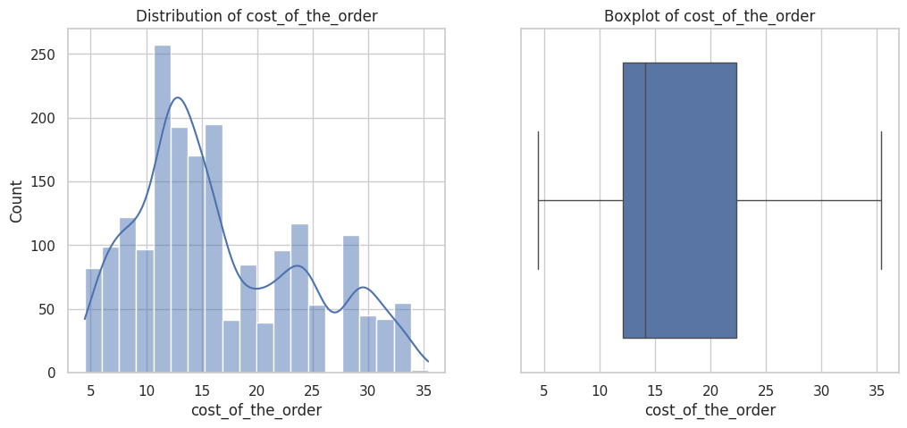

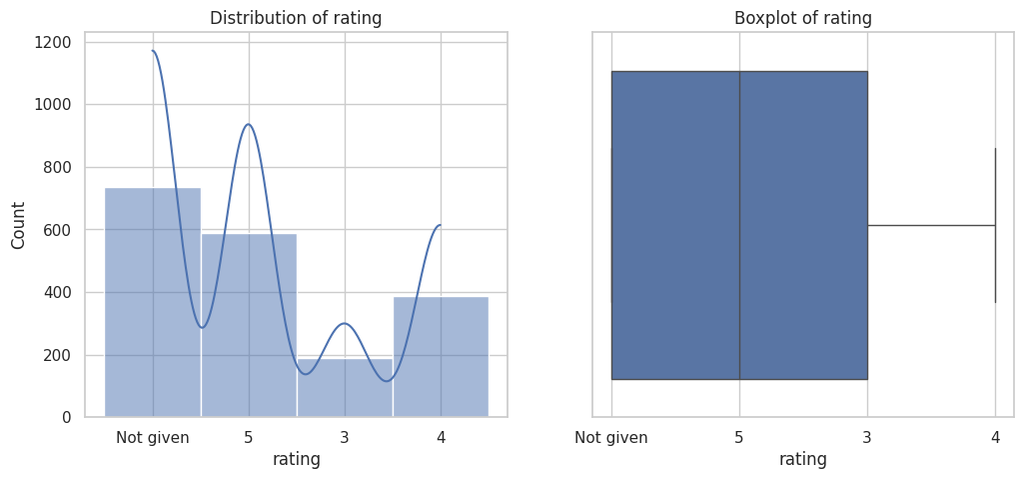

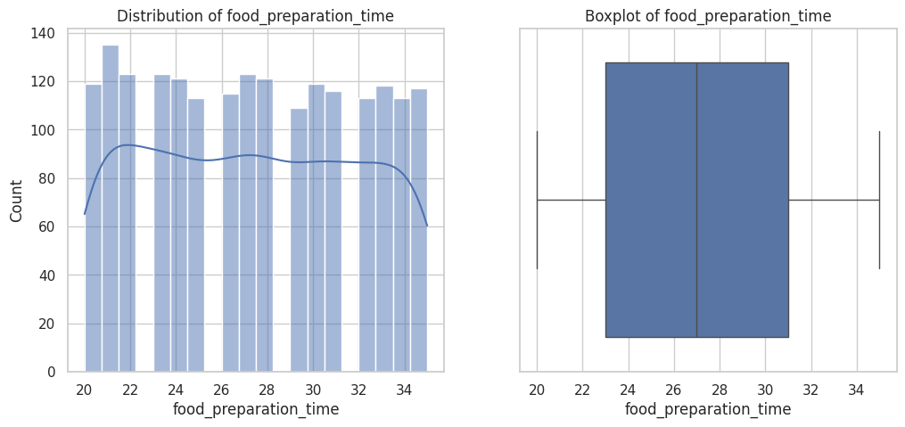

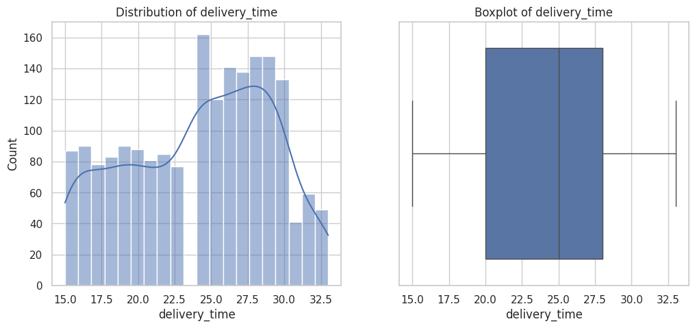

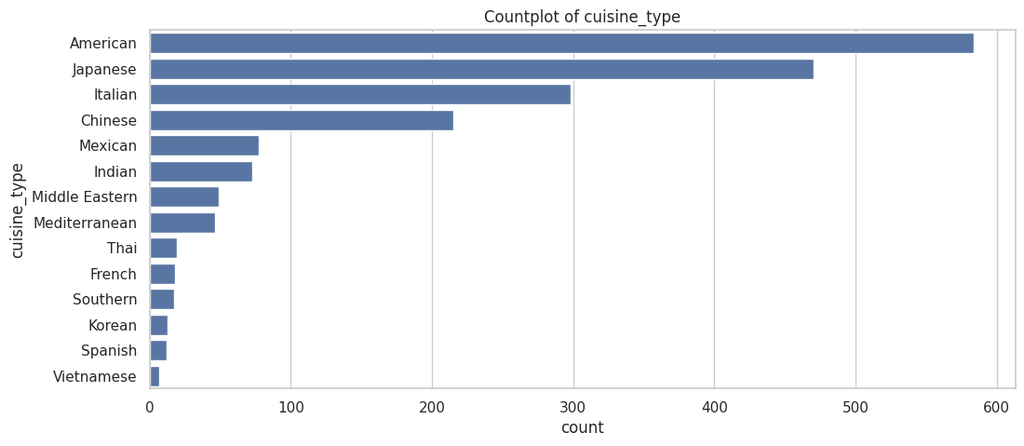

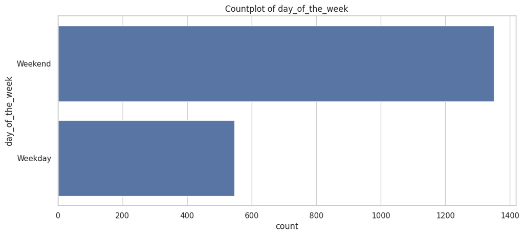

```python
# Set a clean style
sns.set(style="whitegrid")

# 1. Numerical variables
num_cols = ["cost_of_the_order", "rating", "food_preparation_time", "delivery_time"]

for col in num_cols:
    plt.figure(figsize=(12,5))

    # Histogram
    plt.subplot(1,2,1)
    sns.histplot(data[col], kde=True, bins=20)
    plt.title(f"Distribution of {col}")

    # Boxplot
    plt.subplot(1,2,2)
    sns.boxplot(x=data[col])
    plt.title(f"Boxplot of {col}")

    plt.show()

# 2. Categorical variables
cat_cols = ["cuisine_type", "day_of_the_week"]

for col in cat_cols:
    plt.figure(figsize=(12,5))
    sns.countplot(y=data[col], order=data[col].value_counts().index)
    plt.title(f"Countplot of {col}")
    plt.show()
```

Observations:

Categorical fields like cuisine_type show that American cuisine occurs the most often.

Orders occur more on weekends than weekdays.

There are a number of "Not given" values in the rating column this greatly affect the analysis on customer rating.

### **Question 7**: Which are the top 5 restaurants in terms of the number of orders received? [1 mark]

```python
# Write the code here
top_resturants = data['restaurant_name'].value_counts().head(5)
top_resturants
```

| restaurant_name | count |
| --- | --- |
| Shake Shack | 219 |
| The Meatball Shop | 132 |
| Blue Ribbon Sushi | 119 |
| Blue Ribbon Fried Chicken | 96 |
| Parm | 68 |

**dtype:** int64

#### Observations:

The top 5 resturants in the dataset are Shake shack,the Meatball Shop, Blue Ribbon Sushi, Blue Ribbon Fried Chicken and Parm. Among then Shake Shack has the highest number of orders.

### **Question 8**: Which is the most popular cuisine on weekends? [1 mark]

```python
# Write the code here
popular_cuisine = data[data['day_of_the_week'] == 'Weekend']['cuisine_type'].value_counts().head(1)
popular_cuisine
```

| cuisine_type | count |
| --- | --- |
| American | 415 |

**dtype:** int64

#### Observations:

The most popular cuisine on weekends is American cuisine

### **Question 9**: What percentage of the orders cost more than 20 dollars? [2 marks]

```python
# Write the code here
order_percentage = (data['cost_of_the_order'] > 20).mean() * 100
print(f"{order_percentage}%")
```

```
29.24130663856691%
```

#### Observations:

The orders costing more than 20 dollars is 29.24%.

### **Question 10**: What is the mean order delivery time? [1 mark]

```python
# Write the code here
data['delivery_time'].mean()
```

```
np.float64(24.161749209694417)
```

#### Observations:

The mean delivery time is 24.161749209694417

### **Question 11:** The company has decided to give 20% discount vouchers to the top 3 most frequent customers. Find the IDs of these customers and the number of orders they placed. [1 mark]

```python
# Write the code here
top_3_customers = data['customer_id'].value_counts().head(3)
print(top_3_customers)
```

```
customer_id
52832    13
47440    10
83287     9
Name: count, dtype: int64
```

#### Observations:

The top 3 most frequent customers have the following IDS and order numbers from the dataset provided. Customer with ID 52832 has 13 orders, Customer with ID 47440 has 10 orders and Customer with ID 83287 has9 orders.

### **Question 12**: Perform a multivariate analysis to explore relationships between the important variables in the dataset. (It is a good idea to explore relations between numerical variables as well as relations between numerical and categorical variables) [10 marks]

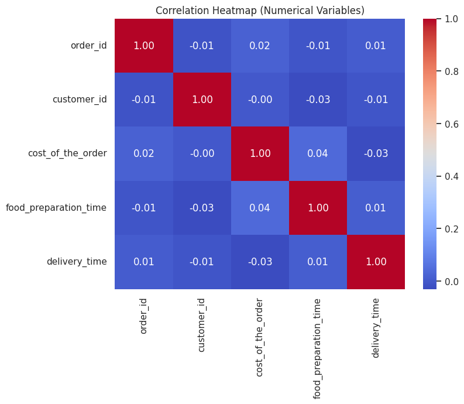

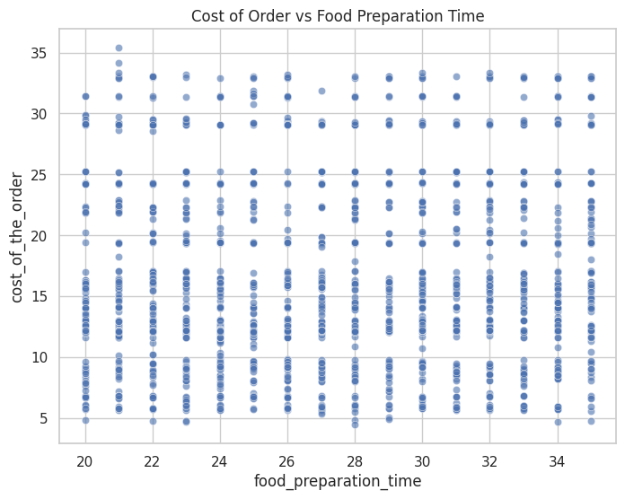

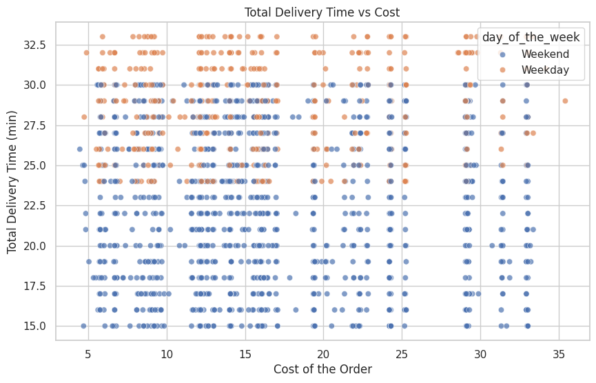

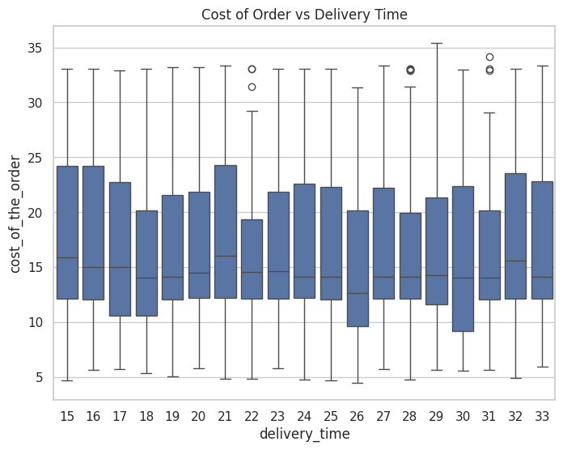

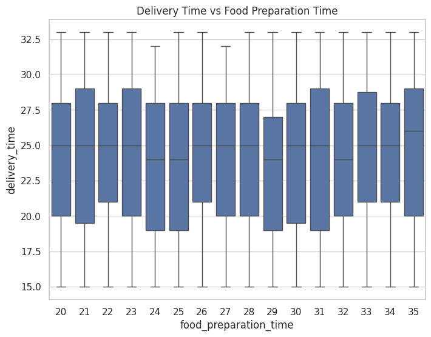

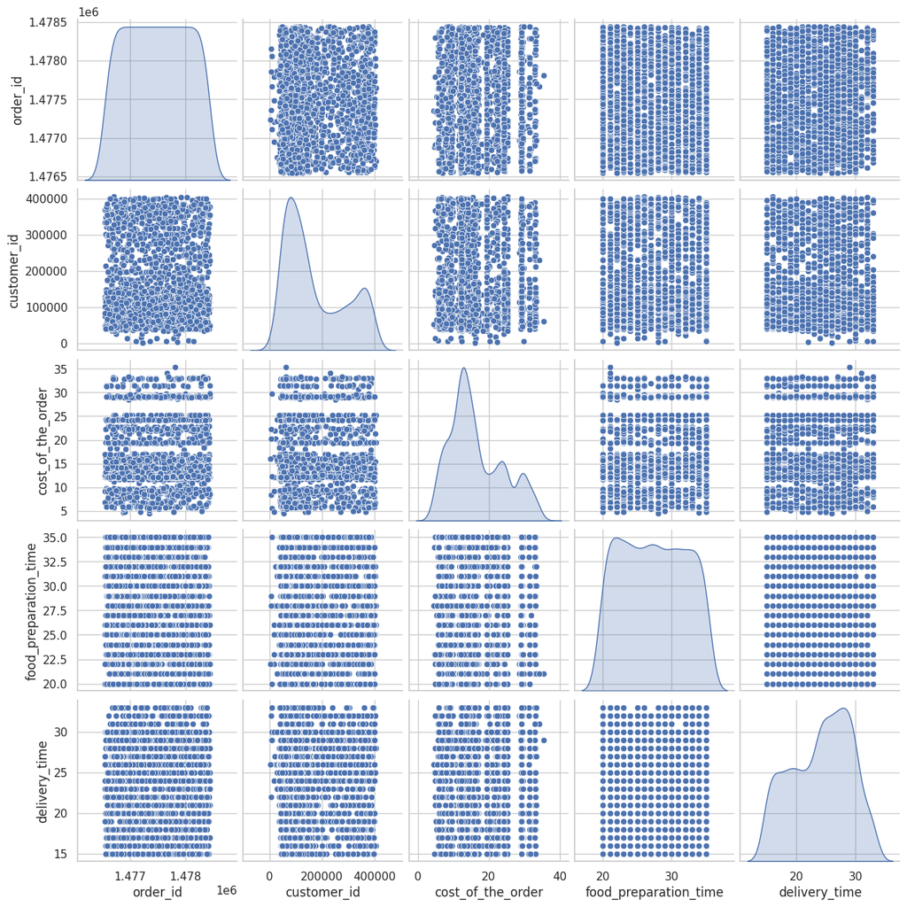

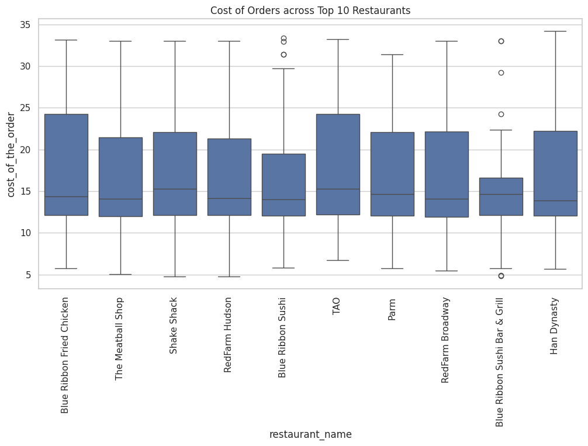

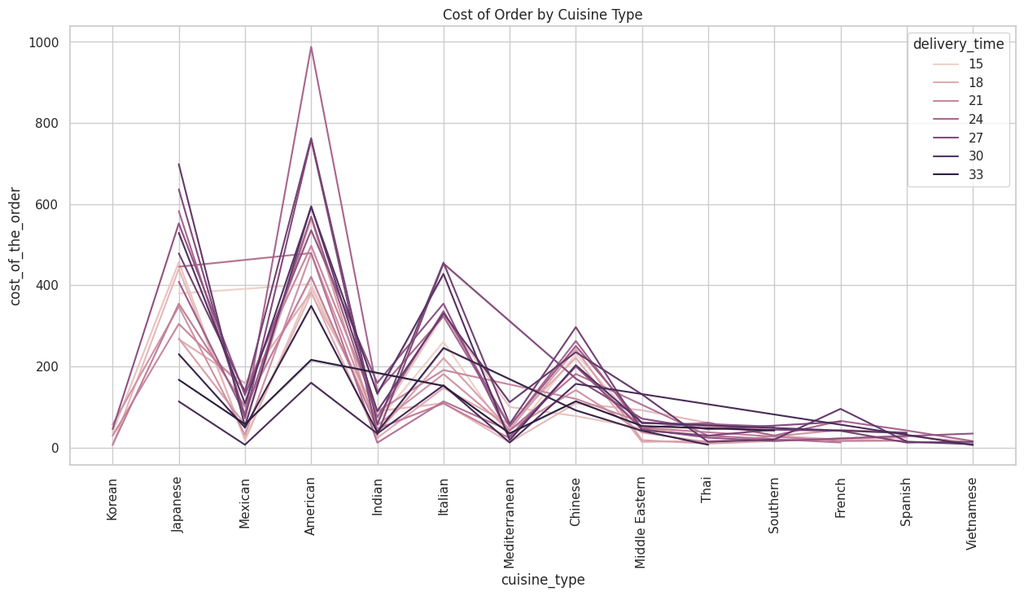

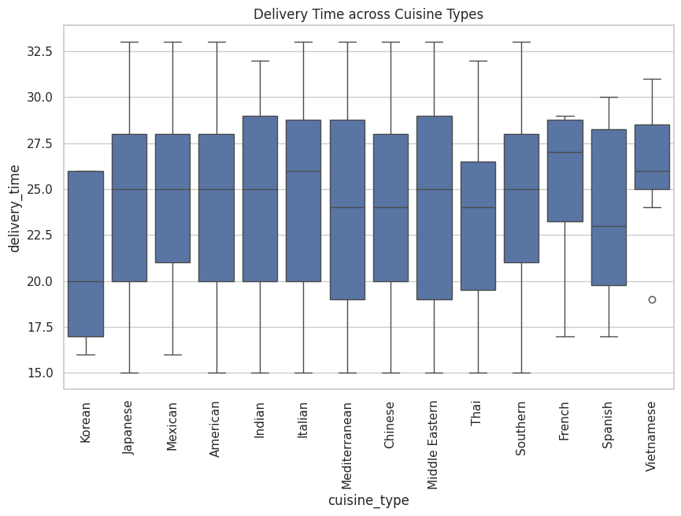

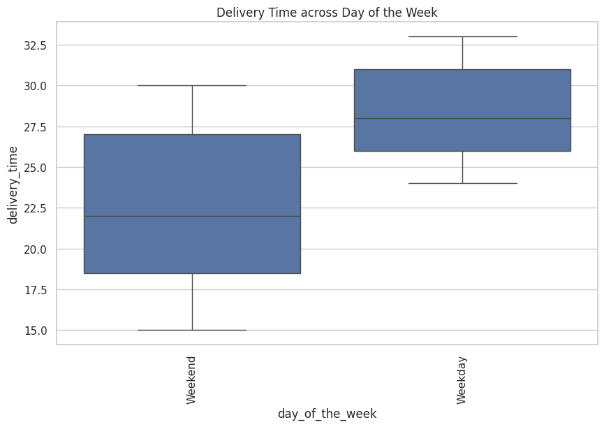

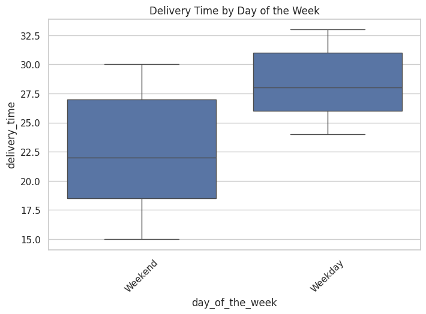

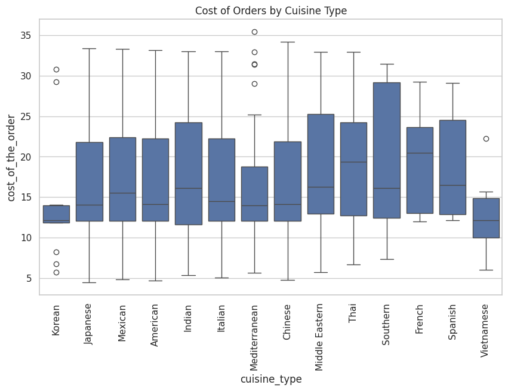

[1 more figures not shown]

```python
# Numerical vs Numerical
# Correlation heatmap for numerical variables

plt.figure(figsize=(8,6))
sns.heatmap(data.corr(numeric_only=True), annot=True, cmap="coolwarm", fmt=".2f")
plt.title("Correlation Heatmap (Numerical Variables)")
plt.show()

# Scatterplot for two important numerical features cost_of_the_order &
# food_preparation_time
if 'cost_of_the_order' in data.columns and 'food_preparation_time' in data.columns:
    plt.figure(figsize=(8,6))
    sns.scatterplot(x="food_preparation_time", y="cost_of_the_order", data=data, alpha=0.6)
    plt.title("Cost of Order vs Food Preparation Time")
    plt.show()

# Scartterplot of Delivery Time vs Cost of the order
plt.figure(figsize=(10, 6))
sns.scatterplot(x='cost_of_the_order', y='delivery_time', data=data, hue='day_of_the_week', alpha=0.7)
plt.title('Total Delivery Time vs Cost')
plt.xlabel('Cost of the Order')
plt.ylabel('Total Delivery Time (min)')
plt.show()

# Delivery Time vs Cost of the order
plt.figure(figsize=(8,6))
sns.boxplot(x="delivery_time", y="cost_of_the_order", data=data)
plt.title("Cost of Order vs Delivery Time")
plt.show()

# Delivery Time vs Food Preparation Time
plt.figure(figsize=(8,6))
sns.boxplot(x="food_preparation_time", y="delivery_time", data=data)
plt.title("Delivery Time vs Food Preparation Time")
plt.show()

# Pairplot to see relationships among key numerical variables
num_cols = data.select_dtypes(include=['int64','float64']).columns
sns.pairplot(data[num_cols], diag_kind="kde")
plt.show()

#. Numerical vs Categorical Analysis

# Boxplot of order cost across different restaurants
top_10_restaurants = data['restaurant_name'].value_counts().head(10).index
plt.figure(figsize=(12,6))
sns.boxplot(x="restaurant_name", y="cost_of_the_order",data=data[data['restaurant_name'].isin(top_10_restaurants)])
plt.xticks(rotation=90)
plt.title("Cost of Orders across Top 10 Restaurants")
plt.show()

# Line plot
plt.figure(figsize=(15,7))
sns.lineplot(data=data, x="cuisine_type", y="cost_of_the_order", hue='delivery_time', estimator='sum', ci=False)
plt.title('Cost of Order by Cuisine Type')
plt.xticks(rotation=90)
plt.show()


# Delivery time vs Categorical variable (cuisine_type)
plt.figure(figsize=(10,6))
sns.boxplot(x="cuisine_type", y="delivery_time", data=data)
plt.xticks(rotation=90)
plt.title("Delivery Time across Cuisine Types")
plt.show()

# Day of the week vs Delivery Time
plt.figure(figsize=(10,6))
sns.boxplot(x="day_of_the_week", y="delivery_time", data=data)
plt.xticks(rotation=90)
plt.title("Delivery Time across Day of the Week")

# Boxplot of delivery time vs day_of_the_week
plt.figure(figsize=(8,5))
sns.boxplot(x="day_of_the_week", y="delivery_time", data=data)
plt.title("Delivery Time by Day of the Week")
plt.xticks(rotation=45)
plt.show()

# Boxplotof cost of order vs cuisine type
plt.figure(figsize=(10,6))
sns.boxplot(x="cuisine_type", y="cost_of_the_order", data=data)
plt.title("Cost of Orders by Cuisine Type")
plt.xticks(rotation=90)
plt.show()

# Boxplotof Food Preparation Time vs Cuisine type
plt.figure(figsize=(14, 7))
sns.boxplot(x='cuisine_type', y='food_preparation_time', data=data)
plt.title('Food Preparation Time by Cuisine Type')
plt.xlabel('Cuisine Type')
plt.ylabel('Preparation Time (min)')
plt.xticks(rotation=45)
plt.show()
```

### **Question 13:** The company wants to provide a promotional offer in the advertisement of the restaurants. The condition to get the offer is that the restaurants must have a rating count of more than 50 and the average rating should be greater than 4. Find the restaurants fulfilling the criteria to get the promotional offer. [3 marks]

```python
# Write the code here
data['rating_convert'] = pd.to_numeric(data['rating'], errors='coerce')
# We need to group by restaurant to calculate rating count and average rating
restaurant_stats = data.groupby('restaurant_name').agg(
    rating_count=('rating_convert', 'count'),
    avg_rating=('rating_convert', 'mean')
).reset_index()
restaurant_stats.columns = ['restaurant_name', 'rating_count', 'average_rating']
# Filter restaurants based on the conditions
promotional_restaurants = restaurant_stats[(restaurant_stats['rating_count'] > 50) & (restaurant_stats['average_rating'] > 4)]

# Print the result
print(promotional_restaurants)
```

```
               restaurant_name  rating_count  average_rating
20   Blue Ribbon Fried Chicken            64        4.328125
21           Blue Ribbon Sushi            73        4.219178
136                Shake Shack           133        4.278195
153          The Meatball Shop            84        4.511905
```

#### Observations:

Four of the restaurants are eligible for the promotion.

• Blue Ribbon Fried Chicken, 64 reviews, average review 4.33 • Blue Ribbon Sushi, 73 reviews, average rating 4.22 • Shake Shack, 133 reviews, 4.28 average rating • The Meatball Shop, 84 reviews, average rating 4.51

### **Question 14:** The company charges the restaurant 25% on the orders having cost greater than 20 dollars and 15% on the orders having cost greater than 5 dollars. Find the net revenue generated by the company across all orders. [3 marks]

```python
# Write the code here
data['commission'] = data['cost_of_the_order'].apply(
    lambda x: x * 0.25 if x > 20 else (x * 0.15 if x > 5 else 0)
)

# Calculate net revenue
net_revenue = data['commission'].sum()

print(f"Net revenue generated by the company across all orders: {net_revenue:.2f}")
```

```
Net revenue generated by the company across all orders: 6166.30
```

#### Observations:

The net revenue after applying 25% on orders costing more than 20 dollars and 15% on the orders having cost greater than 5 dollars is 6166.30

### **Question 15:** The company wants to analyze the total time required to deliver the food. What percentage of orders take more than 60 minutes to get delivered from the time the order is placed? (The food has to be prepared and then delivered.) [2 marks]

```python
# Write the code here
data["total_time"] = data["food_preparation_time"] + data["delivery_time"]
orders_over_60 = (data["total_time"] > 60).sum()
total_orders = len(data)
percentage_over_60 = (orders_over_60 / total_orders) * 100
print(f"Percentage of orders taking more than 60 mins: {percentage_over_60:.2f}%")
```

```
Percentage of orders taking more than 60 mins: 10.54%
```

#### Observations:

Based on the analysis 10.54% of the orders have a total delivery time exceeding 60 minutes, encompassing both food preparation and delivery phases.

### **Question 16:** The company wants to analyze the delivery time of the orders on weekdays and weekends. How does the mean delivery time vary during weekdays and weekends? [2 marks]

```python
# Write the code here
mean_delivery = data.groupby("day_of_the_week")["delivery_time"].mean().reset_index()
print(mean_delivery)
```

```
  day_of_the_week  delivery_time
0         Weekday      28.340037
1         Weekend      22.470022
```

### Recommendations:

1. Create a system of gathering more ratings from the customers. This will provide more consolidated data. Provide a small incentive to the customers for rating orders.
2. Focus more on popular cuisine like American and Japanese to boost revenue throughing higher sales.For less popular cuisine such as Vietnamese or French, determine the reason behind the low orders. Run targeted campaigns to take them to the top.
3. Remove the long waiting time for certain orders. Food preparation processes for restaurants that take more than 30 minutes to prepare must be optimized. It will enhance the overall customer experience.
4. Take advantage of positive reviews by featuring highly rated restaurants in your app. Show great customers' reviews to build trust.
5. Use promotions to enhance weekday orders. This will spread demand evenly across the week.

```python
## !jupyter nbconvert --to html '/content/drive/MyDrive/Colab Notebooks/EDA/PYF_Project_LearnerNotebook_FullCode.ipynb'
```